# 1. Installation & Environment Setup

Set up the python environment, install libraries, connect storage etc.

## Install Libraries

```python
!pip install pgmpy==0.1.23  # Figure out why only this old version seems to work with DAG

# !pip install pgmpy      # ~ for DAGs
!pip install networkx   # ~ for NetworkX DiGraph
!pip install matplotlib # ~ for drawing/plotting graph
!pip install gspread pandas pgmpy
```

### Install GraphViz & PyDot

```python
# https://pypi.python.org/pypi/pydot
!apt-get -qq install -y graphviz && pip install pydot
import pydot
```

## Sync with GitHub Repository

## Authenticate & Link With Google Drive (For Interactive Sheets)

```python
!pip install --upgrade gspread pandas google-auth google-colab

import gspread
import pandas as pd
import numpy as np


from google.colab import auth
from google.auth import default

# Authenticate user
auth.authenticate_user()

# Set up gspread authorization
creds, _ = default()
gc = gspread.authorize(creds)


# Replace with your actual shared Google Sheet ID
spreadsheet_id = '1Is4iHkPOAWx7TiuNIa8ND-OiLkvrwoZ25aXBqrgZuv4'

# Open the Google spreadsheet by ID
spreadsheet = gc.open_by_key(spreadsheet_id)

# Get the worksheet object (e.g., the first sheet)
worksheet = spreadsheet.get_worksheet(0)

# Get all values from the worksheet
data = worksheet.get_all_values()

# Create a Pandas DataFrame
# Assuming the first row contains column headers
df = pd.DataFrame(data[1:], columns=data[0])

# Now you can work with the DataFrame 'df'
print(df)
```

```
  Using cached pandas-2.2.3-cp310-cp310-manylinux_2_17_x86_64.manylinux2014_x86_64.whl.metadata (89 kB)
  Using cached google_auth-2.36.0-py2.py3-none-any.whl.metadata (4.7 kB)
   UniqueID Nodes(Events) Prior / Probability (Mean)
0                       A
1                       B
2                       C
3                       D
4                     ...
5                       X
6                       Y
7                       Z
8                     ...
9                      A'
10                     B'
11                     C'
12
13                    A''
```

```python
!pip install --upgrade gspread pandas google-auth google-colab

import gspread
import pandas as pd
import numpy as np


from google.colab import auth
from google.auth import default
from google.colab import data_table
from google.colab import sheets

# Authenticate user
auth.authenticate_user()

# Set up gspread authorization
creds, _ = default()
gc = gspread.authorize(creds)


sheet = sheets.InteractiveSheet(title='01Extraction', include_column_headers=True)


# Create a Pandas DataFrame
# Assuming the first row contains column headers
df = pd.DataFrame(data[1:], columns=data[0])

# Now you can work with the DataFrame 'df'
print(df)
```

```
  Using cached pandas-2.2.3-cp310-cp310-manylinux_2_17_x86_64.manylinux2014_x86_64.whl.metadata (89 kB)
  Using cached google_auth-2.36.0-py2.py3-none-any.whl.metadata (4.7 kB)
https://docs.google.com/spreadsheets/d/1Is4iHkPOAWx7TiuNIa8ND-OiLkvrwoZ25aXBqrgZuv4#gid=0
```

[interactive chart not shown]

```
   UniqueID Nodes(Events) Prior / Probability (Mean)
0                       A
1                       B
2                       C
3                       D
4                     ...
5                       X
6                       Y
7                       Z
8                     ...
9                      A'
10                     B'
11                     C'
12
13                    A''
```

# Update & Display Data

## Display Interactive Sheet

```python
sheet = sheets.InteractiveSheet(title='01Extraction', include_column_headers=True)
```

```
https://docs.google.com/spreadsheets/d/1Is4iHkPOAWx7TiuNIa8ND-OiLkvrwoZ25aXBqrgZuv4#gid=0
```

[interactive chart not shown]

Documentation:

https://colab.research.google.com/notebooks/io.ipynb#scrollTo=InteractiveSheet

## Update & Display Dataframe

```python
# Replace with your actual shared Google Sheet ID
spreadsheet_id = '1Is4iHkPOAWx7TiuNIa8ND-OiLkvrwoZ25aXBqrgZuv4'

# Open the Google spreadsheet by ID
spreadsheet = gc.open_by_key(spreadsheet_id)

# Get the worksheet object (e.g., the first sheet)
worksheet = spreadsheet.get_worksheet(0)

# Get all values from the worksheet
data = worksheet.get_all_values()

# Create a Pandas DataFrame
# Assuming the first row contains column headers
df = pd.DataFrame(data[1:], columns=data[0])

# Now you can work with the DataFrame 'df'
print(df)
```

```
   UniqueID Nodes(Events) Probability (Mean)
0                       A
1                       B
2                       C
3                       D
4                     ...
5                       X
6                       Y
7                       Z
8                     ...
9                      A'
10                     B'
11                     C'
12
13                    A''
```

```python
sheet = sheets.InteractiveSheet(title='01Extraction', include_column_headers=True)


# Create a Pandas DataFrame
# Assuming the first row contains column headers
df = pd.DataFrame(data[1:], columns=data[0])

# Now you can work with the DataFrame 'df'
print(df)
```

```
https://docs.google.com/spreadsheets/d/1Is4iHkPOAWx7TiuNIa8ND-OiLkvrwoZ25aXBqrgZuv4#gid=0
```

[interactive chart not shown]

[output not shown]

# 2. Defining/Loading the Nodes and Edges

Define the nodes and edges that characterize the network (as per the chains identified).

Nodes: ~ (true / likely) facts about the world Edges: ~ relationships between facts about the world (e.g. how A causes B and C).

## Load Libraries

```python
!pip install pgmpy==0.1.23  # Figure out why only this old version seems to work with DAG
import networkx as nx
import matplotlib.pyplot as plt
from pgmpy.base import DAG  # Import DAG from pgmpy.base instead of pgmpy.models
from pgmpy.models import BayesianNetwork
from pgmpy.factors.discrete import TabularCPD
```

## Create pgmpy DAG from Spreadsheet Data

```python
# Load data from the Google Sheet with nodes
node_sheet_name = '01Extraction'  # Replace with your node sheet name
nodes_worksheet = gc.open(node_sheet_name).Nodes
nodes_data = nodes_worksheet.col_values(2)  # Assuming nodes are in the first column
print("Nodes:", nodes_data)

# Load data from the Google Sheet with adjacency matrix
matrix_sheet_name = '01Extraction'  # Replace with your matrix sheet name
matrix_worksheet = gc.open(matrix_sheet_name).EdgesMatrix
matrix_data = matrix_worksheet.get_all_values()  # Load the matrix as a list of lists
matrix_df = pd.DataFrame(matrix_data[1:], columns=matrix_data[0])  # Convert to DataFrame, skipping header row
print("Adjacency Matrix:\n", matrix_df.head())
```

[output not shown]

```python
import pandas as pd
import json

# Assuming you have 'sheet' as your InteractiveSheet object

# Get the grid options for the sheet
grid_options = sheet.get_grid_options()

# Access the data directly from gridOptions
# The structure depends on the specific library, but usually
# there's a field like 'rowData' containing the actual data
data = json.loads(grid_options)['rowData']

# Assuming the first row contains column headers
df = pd.DataFrame(data[1:], columns=data[0])

# Extract nodes and edges data
nodes_data = df['Nodes'].tolist()  # Assuming your nodes column is named 'Nodes'
# Assuming your edges are represented in columns after 'Nodes'
edges_data = df[df.columns[df.columns.get_loc('Nodes') + 1:]].values.tolist()

print("Nodes:", nodes_data)
print("Edges Data:", edges_data)
```

[output not shown]

```python
!pip install ipyaggrid

from ipyaggrid import Grid  # Import Grid from ipyaggrid
from google.colab import auth
from oauth2client.client import GoogleCredentials
import gspread
from google.auth import default
import json
import pandas as pd

# Authenticate user
auth.authenticate_user()

# Set up gspread authorization
creds, _ = default()
gc = gspread.authorize(creds)

# Replace with your actual shared Google Sheet ID
spreadsheet_id = '1Is4iHkPOAWx7TiuNIa8ND-OiLkvrwoZ25aXBqrgZuv4'

# Open the Google spreadsheet by ID
spreadsheet = gc.open_by_key(spreadsheet_id)

# Select the 'Nodes' worksheet and extract nodes data
nodes_worksheet = spreadsheet.worksheet('Nodes')
nodes_data = nodes_worksheet.get_all_values()
nodes_df = pd.DataFrame(nodes_data[1:], columns=nodes_data[0])
nodes_list = nodes_df['Nodes(Events)'].tolist()

# Select the 'EdgesMatrix' worksheet and extract edges data as a matrix
edges_worksheet = spreadsheet.worksheet('EdgesMatrix')
edges_data = edges_worksheet.get_all_values()
edges_df = pd.DataFrame(edges_data[1:], columns=edges_data[0])

# Create the edges matrix
edges_matrix = edges_df[nodes_list].values.tolist() # Select columns corresponding to nodes

print("Nodes:", nodes_list)
print("Edges Matrix:")
for row in edges_matrix:
    print(row)
```

```
Nodes: ['A', 'B', 'C', 'D', 'E', 'X', 'Y', 'Z', '...', "A'", "B'", "C'", '.......', "A''"]
Edges Matrix:
['', 'P( A | B) = ', 'P( A | B) =', '', '1', '', '', '', '', "P( A | A') =", "P( A | B') =", '', '', '']
['', '', '2', '', '', '', '', '2', '', '', '', '2', '', '2']
['', '', '', '', '', '2', '', '', '', '', '', '', '', '']
['', '', '', '', '', '', '', '', '1', '', '', '', '', '']
['', '', '', '', '', '', '', '', '', '', '', '2', '', '2']
['', '', '', '', '', '', '2', '', '', '2', '', '', '', '']
['', '', '', '', '', '', '', '', '', '', '', '', '1', '']
['', '', '', '', '', '', '', '', '', '', '', '', '', '2']
['', '', '', '', '', '', '', '', '', '', '', '', '2', '']
['', '', '', '', '', '', '', '', '', '', '', '', '', '']
['', '', '', '', '', '', '', '', '', '', '', '', '', '2']
['', '', '', '', '', '', '', '', '', '', '', '', '', '3']
['', '', '', '', '', '', '', '', '', '', '', '', '', '1']
['', '', '', '', '', '', '', '', '', '', '', '', '', '']
```

## Parse the Adjacency Matrix for Edges

```python
from pgmpy.models import BayesianNetwork

# Initialize an empty list for edges
edges = []

# Parse edges based on non-empty cells in the matrix
for i, source_node in enumerate(nodes_list):
    for j, target_node in enumerate(nodes_list):
        cell_value = edges_matrix[i][j]
        if cell_value:  # If the cell contains text, assume an edge exists
            edges.append((target_node, source_node))  # Directed edge from source to target
print("Extracted edges:", edges)
```

[output not shown]

Create a Bayesian Network with pgmpy

```python
# Define the Bayesian Network with the extracted edges
model = BayesianNetwork(edges)
print("Bayesian Network nodes:", model.nodes())
print("Bayesian Network edges:", model.edges())
```

[output not shown]

Identify and Separate Self-Loops

```python
# Filter out self-loop edges
filtered_edges = [(source, target) for source, target in edges if source != target]

# Define the Bayesian Network with the filtered edges
model = BayesianNetwork(filtered_edges)
print("Bayesian Network nodes:", model.nodes())
print("Bayesian Network edges:", model.edges())
```

[output not shown]

```python
# Identify self-loop edges
self_loops = [(source, target) for source, target in edges if source == target]
# Filter out self-loop edges
filtered_edges = [(source, target) for source, target in edges if source != target]

# Print the removed self-loops and the filtered edges
print("Self-loops removed:")
for loop in self_loops:
    print(loop)

print("\nFiltered edges (no self-loops):")
for edge in filtered_edges:
    print(edge)
```

```
Self-loops removed:

Filtered edges (no self-loops):
('B', 'A')
('C', 'A')
('E', 'A')
("A'", 'A')
("B'", 'A')
('C', 'B')
('Z', 'B')
("C'", 'B')
("A''", 'B')
('X', 'C')
('...', 'D')
("C'", 'E')
("A''", 'E')
('Y', 'X')
("A'", 'X')
('.......', 'Y')
("A''", 'Z')
('.......', '...')
("A''", "B'")
("A''", "C'")
("A''", '.......')
```

Visualize the Graph Using networkx and matplotlib

# 3. Visualizing the Network

You can visualize the network using matplotlib and networkx.

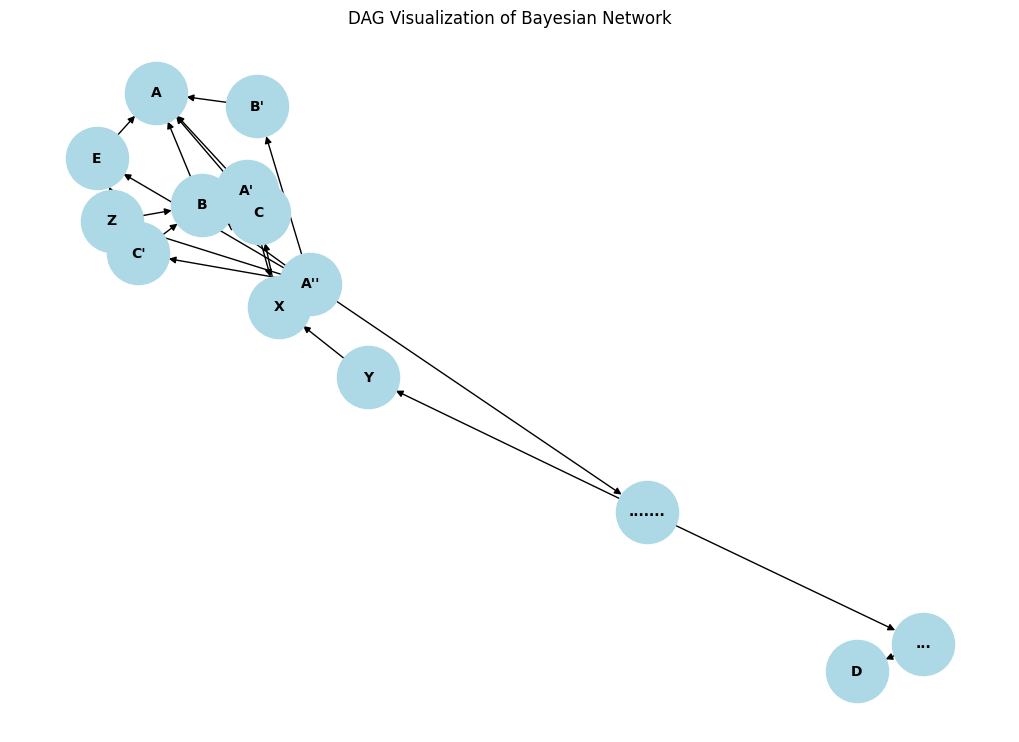

```python
import networkx as nx
import matplotlib.pyplot as plt

# Convert pgmpy DAG to a NetworkX graph for visualization
nx_graph = nx.DiGraph(model.edges())

pos = nx.nx_pydot.graphviz_layout(nx_dag, prog='dot')



# Plot the graph
plt.figure(figsize=(10, 7))
nx.draw(nx_graph, with_labels=True, node_size=2000, node_color='lightblue', font_size=10, font_weight='bold')
plt.title("DAG Visualization of Bayesian Network")
plt.show()
```

```python
!pip install pyvis
```

```python
from pyvis.network import Network
import networkx as nx

# Create a NetworkX graph using the filtered edges
nx_graph = nx.DiGraph(filtered_edges)

# Initialize Pyvis Network with cdn_resources set to "in_line"
net = Network(notebook=True, directed=True, cdn_resources="in_line")

# Load the NetworkX graph into Pyvis
net.from_nx(nx_graph)

# Customize layout and physics
net.force_atlas_2based(gravity=-50)
net.show_buttons(filter_=['physics'])

# Display the interactive graph directly in the notebook
net.show("interactive_dag.html")
```

```
interactive_dag.html
```

[interactive chart not shown]

## Display HTML graph in Colab

```python
from pyvis.network import Network
import networkx as nx
from IPython.display import HTML

# Create and configure the graph with Pyvis
nx_graph = nx.DiGraph(filtered_edges)
net = Network(notebook=True, directed=True, cdn_resources="in_line")
net.from_nx(nx_graph)
net.force_atlas_2based(gravity=-50)
net.show_buttons(filter_=['physics'])

# Save the HTML to a file
net.save_graph("interactive_dag.html")

# Read the HTML file contents and embed it directly
with open("interactive_dag.html", "r") as f:
    html_content = f.read()

# Display the graph as HTML
HTML(html_content)
```

```python
from google.colab import files

# Download the HTML file
files.download("interactive_dag.html")
```

```python
#@title Convert ipynb to HTML in Colab
# Upload ipynb
from google.colab import files
f = files.upload()

# Convert ipynb to html
import subprocess
file0 = list(f.keys())[0]
_ = subprocess.run(["pip", "install", "nbconvert"])
_ = subprocess.run(["jupyter", "nbconvert", file0, "--to", "html"])

# download the html
files.download(file0[:-5]+"html")
```